# Warung Kopi Biodiverskripsi: Eksplorasi Data Perjumpaan

Sabhrina G. Aninta

23 March 2019

## Mengunduh Data Perjumpaan dari Database Daring

Untuk mendapatkan data perjumpaan, kita bisa mengunduh data dari berbagai macam database daring. Dalam contoh ini, kita akan menggunakan data dari **GBIF**. Untuk mengunduh data dari GBIF, kita perlu melakukan registrasi terlebih dahulu sebagai user. Setelah melakukan registrasi, kita bisa mengunduh data yang kita perlukan dengan memanfaatkan query di GBIF.

Kita juga dapat mengunduh data GBIF menggunakan R melalui package [`rgbif`](https://www.gbif.org/tool/81747/rgbif).

```r
library(rgbif)

## mencari data perjumpaan
occ_search(scientificName = "Cynopterus brachyotis", limit = 20)
```

```
## Records found [6141]
## Records returned [20]
## No. unique hierarchies [1]
## No. media records [19]
## No. facets [0]
## Args [limit=20, offset=0, scientificName=Cynopterus brachyotis,
##      fields=all]
## # A tibble: 20 x 74
##       key scientificName decimalLatitude decimalLongitude issues datasetKey
##     <int> <chr>                    <dbl>            <dbl> <chr>  <chr>
##  1 2.01e9 Cynopterus br~            1.45             104. gass84 50c9509d-~
##  2 1.81e9 Cynopterus br~            1.45             104. cdrou~ 50c9509d-~
##  3 1.81e9 Cynopterus br~            1.38             104. cdrou~ 50c9509d-~
##  4 1.84e9 Cynopterus br~            5.99             116. gass84 50c9509d-~
##  5 1.85e9 Cynopterus br~            1.42             104. cdrou~ 50c9509d-~
##  6 1.84e9 Cynopterus br~            1.45             104. cdrou~ 50c9509d-~
##  7 1.84e9 Cynopterus br~            1.45             104. cdrou~ 50c9509d-~
##  8 1.84e9 Cynopterus br~            1.45             104. cdrou~ 50c9509d-~
##  9 1.85e9 Cynopterus br~            1.45             104. cdrou~ 50c9509d-~
## 10 1.85e9 Cynopterus br~            1.41             104. cdrou~ 50c9509d-~
## 11 1.85e9 Cynopterus br~            1.45             104. gass84 50c9509d-~
## 12 1.89e9 Cynopterus br~            1.45             104. cdrou~ 50c9509d-~
## 13 1.90e9 Cynopterus br~            1.38             104. cdrou~ 50c9509d-~
## 14 1.91e9 Cynopterus br~            1.45             104. gass84 50c9509d-~
## 15 1.91e9 Cynopterus br~            1.45             104. gass84 50c9509d-~
## 16 1.91e9 Cynopterus br~            1.45             104. gass84 50c9509d-~
## 17 1.91e9 Cynopterus br~            1.45             104. cdrou~ 50c9509d-~
## 18 1.99e9 Cynopterus br~            1.45             104. cdrou~ 50c9509d-~
## 19 1.57e9 Cynopterus br~            1.42             104. cdrou~ 50c9509d-~
## 20 1.67e9 Cynopterus br~            1.45             104. cdrou~ 50c9509d-~
## # ... with 68 more variables: publishingOrgKey <chr>, networkKeys <chr>,
## #   installationKey <chr>, publishingCountry <chr>, protocol <chr>,
## #   lastCrawled <chr>, lastParsed <chr>, crawlId <int>, extensions <chr>,
## #   basisOfRecord <chr>, taxonKey <int>, kingdomKey <int>,
## #   phylumKey <int>, classKey <int>, orderKey <int>, familyKey <int>,
## #   genusKey <int>, speciesKey <int>, acceptedTaxonKey <int>,
## #   acceptedScientificName <chr>, kingdom <chr>, phylum <chr>,
## #   order <chr>, family <chr>, genus <chr>, species <chr>,
## #   genericName <chr>, specificEpithet <chr>, taxonRank <chr>,
## #   taxonomicStatus <chr>, dateIdentified <chr>, stateProvince <chr>,
## #   year <int>, month <int>, day <int>, eventDate <chr>, modified <chr>,
## #   lastInterpreted <chr>, references <chr>, license <chr>,
## #   identifiers <chr>, facts <chr>, relations <chr>, geodeticDatum <chr>,
## #   class <chr>, countryCode <chr>, country <chr>, rightsHolder <chr>,
## #   identifier <chr>, verbatimEventDate <chr>, datasetName <chr>,
## #   collectionCode <chr>, gbifID <chr>, verbatimLocality <chr>,
## #   occurrenceID <chr>, taxonID <chr>, recordedBy <chr>,
## #   catalogNumber <chr>, http...unknown.org.occurrenceDetails <chr>,
## #   institutionCode <chr>, rights <chr>, eventTime <chr>,
## #   identificationID <chr>, name <chr>,
## #   coordinateUncertaintyInMeters <dbl>, occurrenceRemarks <chr>,
## #   informationWithheld <chr>, identificationRemarks <chr>
```

```r
chiropteraID<-occ_search(scientificName = "Chiroptera", country = "ID", limit=20)
name_suggest(q='Cynopterus', rank='species')
```

```
## # A tibble: 23 x 3
##        key canonicalName             rank
##      <int> <chr>                     <chr>
##  1 2432833 Cynopterus titthaecheilus SPECIES
##  2 8745739 Cynopterus albiventer     SPECIES
##  3 5787446 Cynopterus brachysoma     SPECIES
##  4 5787525 Cynopterus blanfordi      SPECIES
##  5 9212547 Cynopterus babi           SPECIES
##  6 4265710 Cynopterus minutus        SPECIES
##  7 4265693 Cynopterus luzoniensis    SPECIES
##  8 2432837 Cynopterus brachyotis     SPECIES
##  9 8905531 Cynopterus scherzeri      SPECIES
## 10 8849767 Cynopterus persimilis     SPECIES
## # ... with 13 more rows
```

```r
## mengecek hasil pencarian yang dapat diunduh
my_download<-occ_download_get("0005737-171002173027117",overwrite=TRUE)
```

```
## Download file size: 0.26 MB
```

```
## On disk at D:\TAMBORA\SkrpDat\14 Event - Warung Kopi Biodiverksripsi\warkopBiodiverskripsi\0005737-171002173027117.zip
```

```r
## melihat sitasi dari hasil pencarian
gbif_citation(my_download)
```

[output not shown]

[output cut: 377 more lines]

[output not shown]

## Eksplorasi Data

Salah satu cara eksplorasi data adalah melihat variasi dalam data. Dalam sesi ini, kita akan mengeksplorasi data yang telah dibersihkan.

```r
sulbat<-read.csv("SulawesiBat_cleaned.csv")

library(dplyr)
glimpse(sulbat)
```

```
## Observations: 2,677
## Variables: 106
## $ X.1                              <int> 1, 2, 3, 4, 5, 6, 7, 8, 9, 10...
## $ X                                <int> 1, 2, 3, 4, 5, 6, 7, 8, 9, 10...
## $ type                             <fct> PhysicalObject, PhysicalObjec...
## $ modified                         <fct> 2015-01-06, 2015-01-06, 2015-...
## $ license                          <fct> CCBY, CCBY, CCBY, CCBY, CCBY,...
## $ accessrights                     <fct> , , , , , , , , , , , , , , ,...
## $ bibliographiccitation            <fct> Western Australian Museum. We...
## $ references                       <fct> http://portal.vertnet.org/o/w...
## $ institutionid                    <fct> , , , , , , , , , , , , , , ,...
## $ collectionid                     <fct> , , , , , , , , , , , , , , ,...
## $ datasetid                        <fct> , , , , , , , , , , , , , , ,...
## $ institutioncode                  <fct> WAM, WAM, WAM, WAM, WAM, WAM,...
## $ collectioncode                   <fct> MAMM, MAMM, MAMM, MAMM, MAMM,...
```

[output cut: 93 more lines]

Tampak bahwa dalam data perjumpaan, sebagian besar data berjenis faktor; tidak ada data angka kontinu. Data dapat dikelompokkan dalam beberapa kategori.

```
## Warning: Removed 213 rows containing non-finite values (stat_count).
```

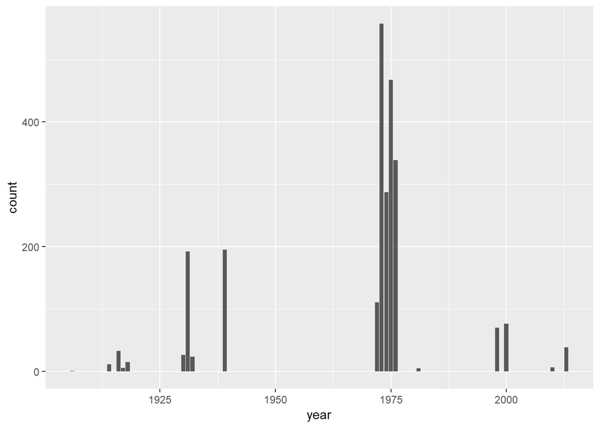

```r
library(ggplot2)
ggplot(data=sulbat) +
  geom_bar(aes(x=year))
```

Ada 213 data perjumpaan yang dihilangkan karena memuat data yang tidak dapat diplotkan ke dalam grafik batang. Dari eksplorasi manual angka-angka ini dengan `dplyr::count()`, tampak bahwa nilai tersebut adalah `NA`. Untuk menghilangkan pesan peringatan keberadaan NA, kita dapat menghilangkan nilai `NA` dalam grafik dengan `na.rm=TRUE`.

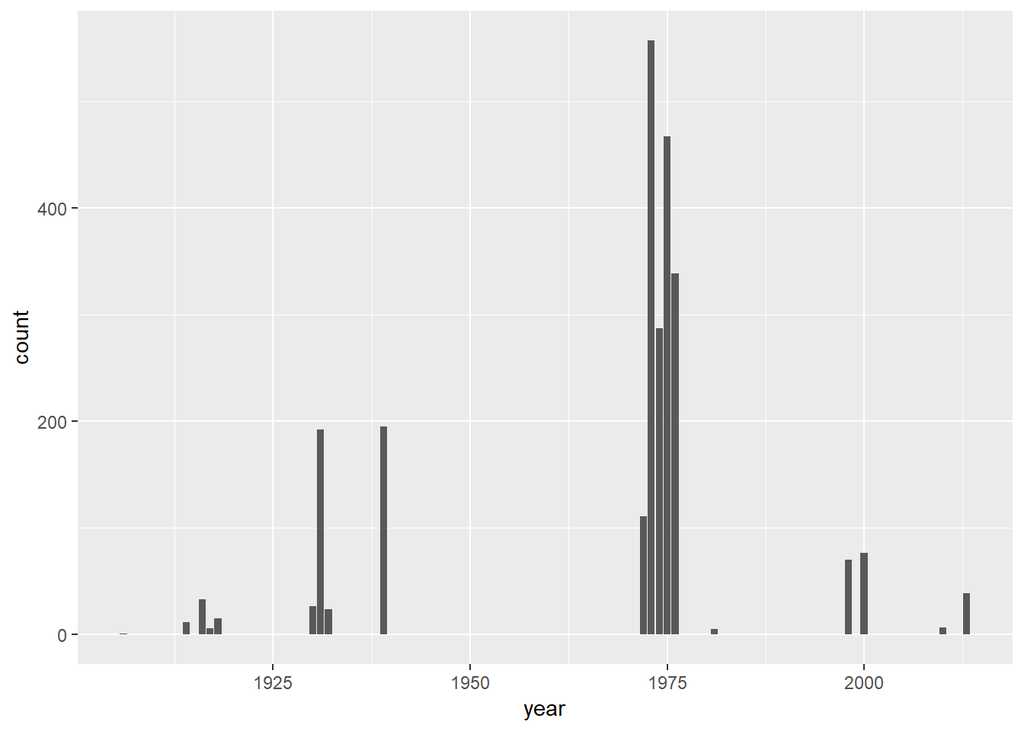

```r
ggplot(data=sulbat) +
  geom_bar(aes(x=year), na.rm = T)
```

Tampak bahwa ada beberapa nilai yang sangat kecil, kita bisa melihat apakah ada data di area tersebut dengan mendefinisikan sumbu y dari 0 hingga 50 data perjumpaan.

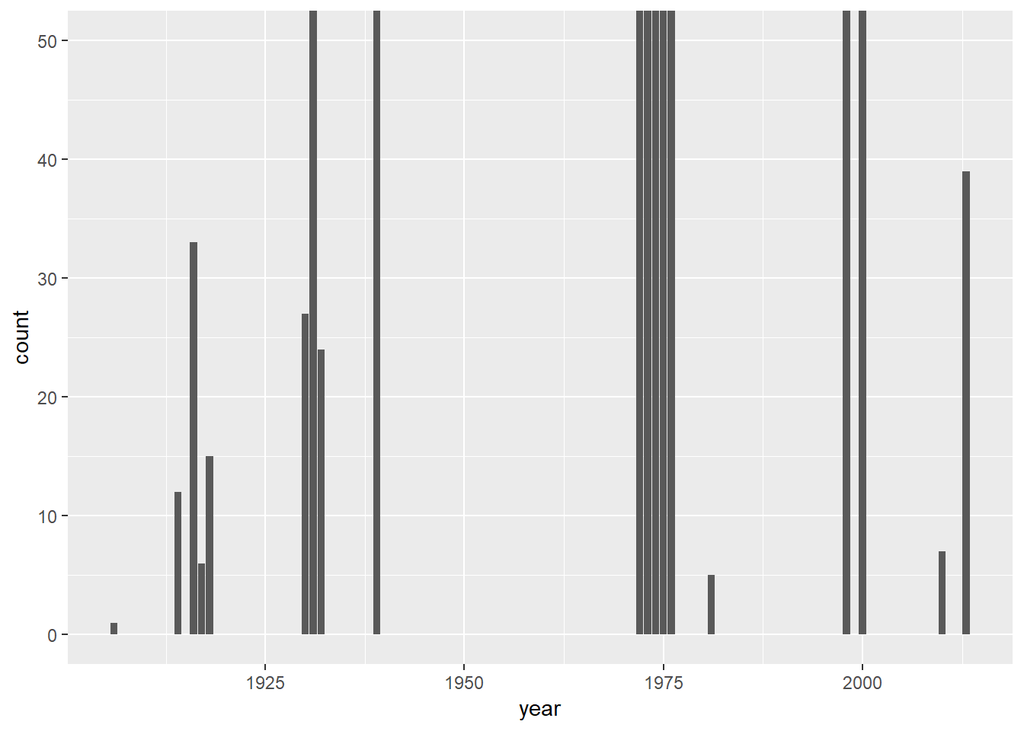

```r
ggplot(data=sulbat) +
  geom_bar(aes(x=year), na.rm = T)+
  coord_cartesian(ylim=c(0,50))
```

Distribusi data berdasarkan tahun tampak sangat bias di pertengahan tahun 1970an dan spesimen tidak merata ada di setiap tahun. Grafik tampak kosong sehingga tidak ada gunanya menskala tahun. Tahun bisa diubah menjadi faktor yang bersifat kategori alih-alih angka kuantitatif.

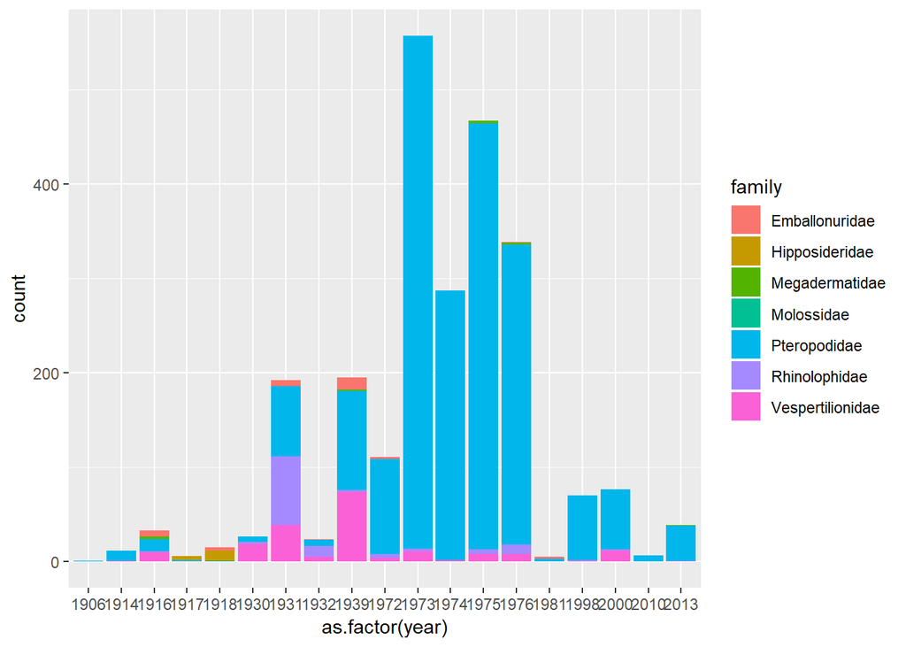

```r
## untuk menghilangkan NA
sulbatYear<-sulbat%>%filter(sulbat$year!="NA")

## untuk ngeplot ulang dengan tahun sebagai faktor
ggplot(data=sulbatYear) +
  geom_bar(aes(x=as.factor(year), fill=family)) ## pakai family karena spesies terlalu banyak
```

```r
## menghitung spesies per tahun
sulbatYear %>% group_by(year) %>% count(speciesname)
```

```
## # A tibble: 174 x 3
## # Groups:   year [19]
##     year speciesname               n
##    <int> <fct>                 <int>
##  1  1906 Pteropus pumilus          1
##  2  1914 Nyctimene cephalotes      3
##  3  1914 Phoniscus jagorii         1
##  4  1914 Rousettus celebensis      2
##  5  1914 Styloctenium wallacei     3
##  6  1914 Thoopterus nigrescens     3
##  7  1916 Emballonura alecto        6
##  8  1916 Megaderma spasma          3
##  9  1916 Myotis ater              10
## 10  1916 Pteropus alecto           2
## # ... with 164 more rows
```

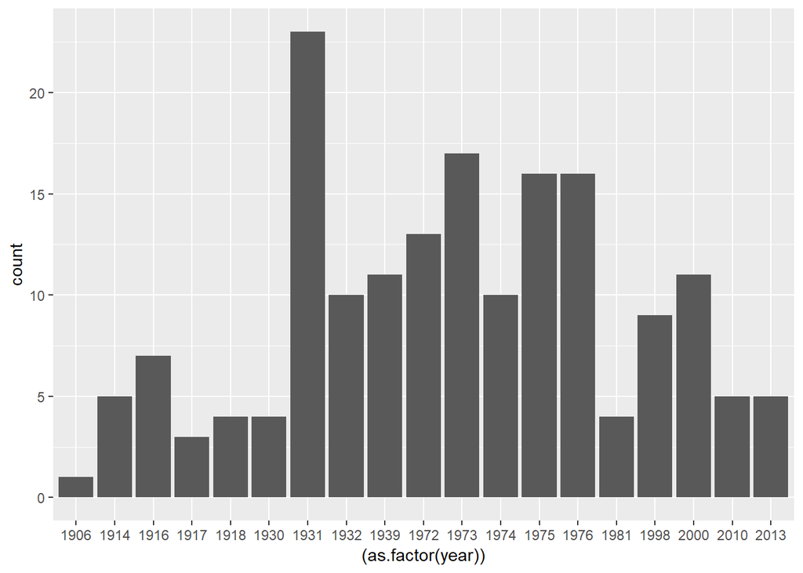

```r
ggplot(sulbatYear %>% group_by(year) %>% count(speciesname))+
  geom_bar(aes(x=(as.factor(year))))
```

Tapi, data tahun tidak tepat ditampilkan demikian karena akan menimbulkan persepsi distribusi kekayaan spesies yang berubah seiring waktu padahal ada bias pencuplikan. Kita ambil saja interval tahun yang cukup kontinu, yakni dari tahun 1972 sampai dengan 1976.

```r
sulbatYear2<-sulbat %>% mutate(year=ifelse(year<1972|year>1976,NA,year))
sulbatYear2 %>% group_by(year) %>% count(speciesname)
```

```
## # A tibble: 119 x 3
## # Groups:   year [6]
##     year speciesname                    n
##    <int> <fct>                      <int>
##  1  1972 Cynopterus brachyotis          6
##  2  1972 Cynopterus luzoniensis         1
##  3  1972 Falsistrellus petersi          1
##  4  1972 Harpyionycteris celebensis     1
##  5  1972 Hipposideros galeritus         2
##  6  1972 Macroglossus minimus           1
##  7  1972 Miniopterus macrocneme         1
##  8  1972 Miniopterus tristis            2
##  9  1972 Rhinolophus euryotis           2
## 10  1972 Rousettus celebensis          77
## # ... with 109 more rows
```

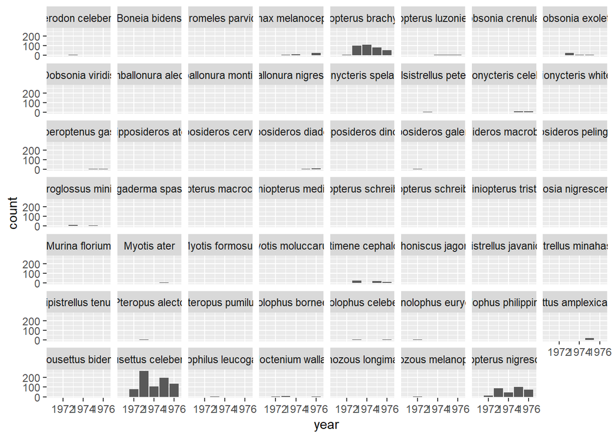

```r
ggplot(data=sulbatYear2) +
  geom_bar(aes(x=year), na.rm = T) +
  facet_wrap(~speciesname)
```

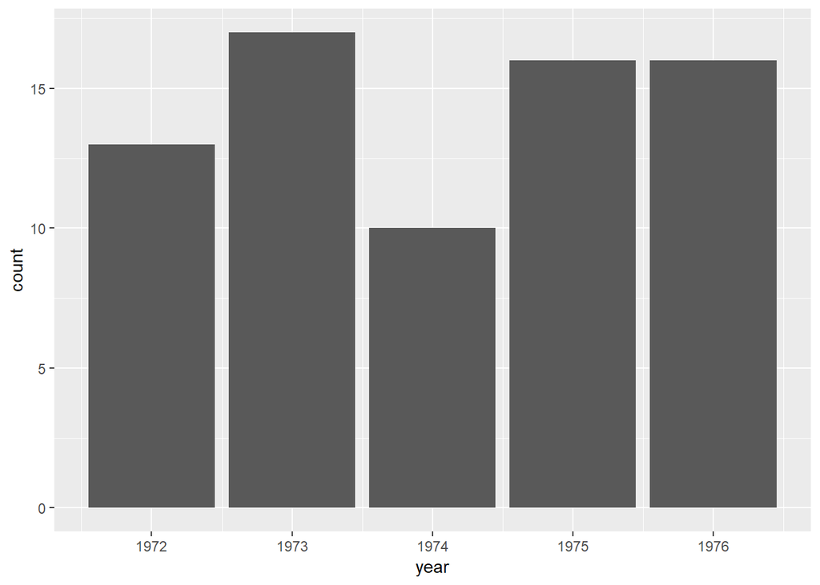

```r
ggplot(sulbatYear2 %>% group_by(year) %>% count(speciesname)) +
  geom_bar(aes(x=year), na.rm=T)
```

```r
# Ada apa di tahun itu kenapa begitu runut ada koleksi?
sulbatYear2%>%group_by(institutioncode)%>%summarise(n=n())
```

```
## # A tibble: 7 x 2
##   institutioncode     n
##   <fct>           <int>
## 1 AMNH             2077
## 2 FMNH               11
## 3 LSUMZ              39
## 4 MSB               147
## 5 MVZ                 7
## 6 USNM              184
## 7 WAM               212
```

```r
sulbatYear2%>%group_by(recordedby)%>%summarise(n=n())
```

```
## # A tibble: 18 x 2
##    recordedby                                      n
##    <fct>                                       <int>
##  1 ""                                            251
##  2 Collector Unknown                             127
##  3 Collector(s): James L. Patton                   7
##  4 Collector(s): Luis A. Ruedas                   84
##  5 Collector(s): Sulawesi 2000                    30
##  6 Collector(s): Sulawesi 2000, Luis A. Ruedas    33
##  7 E. Mearns                                       1
##  8 G. G. Musser                                 1365
##  9 G. Heinrich                                   243
## 10 H. C. Raven                                    11
## 11 H. Raven                                       56
## 12 J. J. Menden                                  195
## 13 KITCHENER,D.J.ET AL                            50
## 14 Mr. Sukaeri                                     1
## 15 NAMRU-2                                        31
## 16 P. F. D. Van Peenen                            22
## 17 Patton, James L.                               39
## 18 SUYANTO,A.                                    131
```

```r
sulbatYear2 %>% group_by(institutioncode) %>% count(recordedby)
```

```
## # A tibble: 18 x 3
## # Groups:   institutioncode [7]
##    institutioncode recordedby                                      n
##    <fct>           <fct>                                       <int>
##  1 AMNH            ""                                            251
##  2 AMNH            G. G. Musser                                 1365
##  3 AMNH            G. Heinrich                                   243
##  4 AMNH            J. J. Menden                                  195
##  5 AMNH            Mr. Sukaeri                                     1
##  6 AMNH            P. F. D. Van Peenen                            22
##  7 FMNH            H. C. Raven                                    11
##  8 LSUMZ           Patton, James L.                               39
##  9 MSB             Collector(s): Luis A. Ruedas                   84
## 10 MSB             Collector(s): Sulawesi 2000                    30
## 11 MSB             Collector(s): Sulawesi 2000, Luis A. Ruedas    33
## 12 MVZ             Collector(s): James L. Patton                   7
## 13 USNM            Collector Unknown                             127
## 14 USNM            E. Mearns                                       1
## 15 USNM            H. Raven                                       56
## 16 WAM             KITCHENER,D.J.ET AL                            50
## 17 WAM             NAMRU-2                                        31
## 18 WAM             SUYANTO,A.                                    131
```

Kita dapat pula melihat perubahan banyaknya jumlah spesies yang dikoleksi seiring waktu.

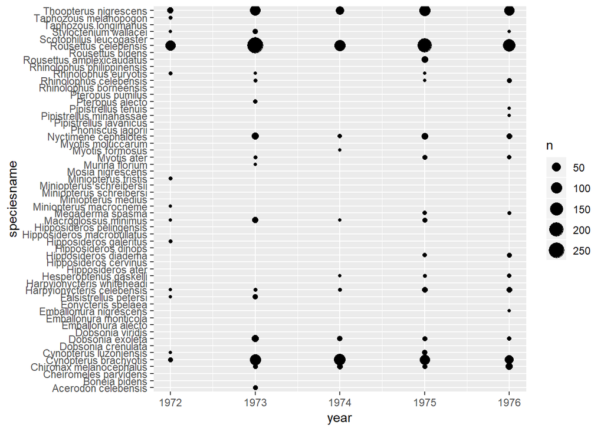

```r
ggplot(sulbatYear2) +
   geom_count(aes(x=year,y=speciesname),na.rm = T)
```

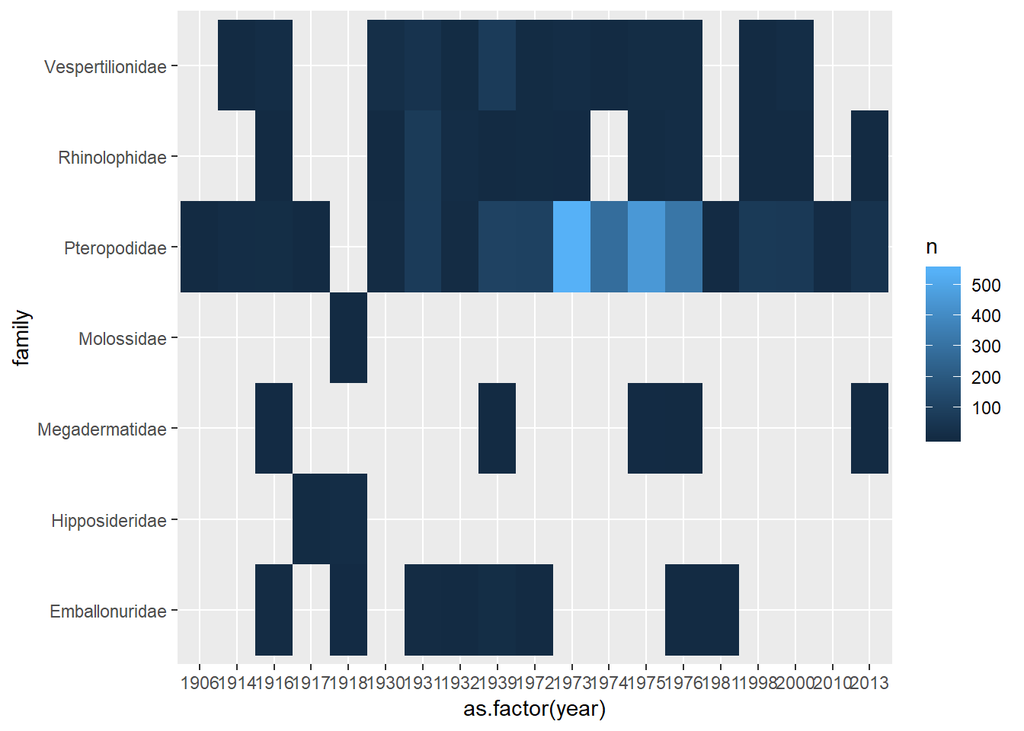

```r
sulbatYear %>% count(year,family) %>% ggplot()+
  geom_tile(aes(x=as.factor(year),y=family,fill=n))
```

## Merapikan Data

Contoh-contoh sebelumnya merupakan data yang sudah dirapikan. Bagaimana dengan data yang belum dirapikan? Apa maksud data yang belum dirapikan dan bagaimana cara membuat data rapi? Saya memberikan informasi tentang bagaimana data dirapikan di “01 SulawesiBats_dataWrangling.R”. Data yang rapi lebih mudah dianalisis dan dipresentasikan dalam bentuk yang mudah dibaca. Perhatikan bahwa selama analisis kita melakukan transformasi data.

*Cheatsheet untuk membuat dokumen Rmarkdown dapat dilihat di [sini](https://www.rstudio.com/wp-content/uploads/2015/02/rmarkdown-cheatsheet.pdf)* *Untuk informasi lebih lanjut, hubungi sagitaninta[at]gmail.com*